# 22_06_03_experiments

# Getters

```r
get_signal1 <- function(x) signals[[x$signal_id1]][1:(x$l_known + x$l_forecast)]
get_signal2 <- function(x) signals[[x$signal_id2]][1:(x$l_known + x$l_forecast)]
get_noise_add1 <- function(x) (x$noise_norm1 * noises[[1]][[x$noise_id]])[1:(x$l_known + x$l_forecast)]
get_noise_add2 <- function(x) (x$noise_norm2 * noises[[2]][[x$noise_id]])[1:(x$l_known + x$l_forecast)]
get_noise_mult1 <- function(x) (1 + x$noise_norm1 * noises[[1]][[x$noise_id]])[1:(x$l_known + x$l_forecast)]
get_noise_mult2 <- function(x) (1 + x$noise_norm2 * noises[[2]][[x$noise_id]])[1:(x$l_known + x$l_forecast)]
get_norm1 <- function(x) 1 / mean(abs(get_signal1(x)[1:x$l_known]))
get_norm2 <- function(x) x$norm_relative / mean(abs(get_signal2(x)[1:x$l_known]))
get_series_add1 <- function(x) get_signal1(x) * x$norm1 + get_noise_add1(x)
get_series_add2 <- function(x) get_signal2(x) * x$norm2 + get_noise_add2(x)
get_series_mult1 <- function(x) get_signal1(x) * get_noise_mult1(x) * x$norm1
get_series_mult2 <- function(x) get_signal2(x) * get_noise_mult2(x) * x$norm2

get_ssa_error_reconstruct <- function(x) {
    MSE(get_signal1(x)[1:x$l_known] * x$norm1,
        reconstruct(ssa(get_series1(x)[1:x$l_known], L = x$l_window),
                    groups = groups[[x$group_ssa_id]])$F1)
}
get_ssa_error_forecast <- function(x) {
    MSE(get_signal1(x)[x$l_known + (1:x$l_forecast)] * x$norm1,
        rforecast(ssa(get_series1(x)[1:x$l_known], L = x$l_window),
                  groups = groups[[x$group_ssa_id]], len = x$l_forecast))
}
get_mssa_error_reconstruct <- function(x) {
    MSE(get_signal1(x)[1:x$l_known] * x$norm1,
        reconstruct(ssa(cbind(get_series1(x)[1:x$l_known],
                              get_series2(x)[1:x$l_known]),
                        L = x$l_window, kind = "mssa"),
                    groups = groups[[x$group_mssa_id]])$F1[, 1])
}
get_mssa_error_forecast <- function(x) {
    MSE(get_signal1(x)[x$l_known + (1:x$l_forecast)] * x$norm1,
        rforecast(ssa(cbind(get_series1(x)[1:x$l_known],
                            get_series2(x)[1:x$l_known]),
                      L = x$l_window, kind = "mssa"),
                  groups = groups[[x$group_mssa_id]], len = x$l_forecast)[, 1])
}
get_relative_error_reconstruct <- function(x) {
    (x$ssa_error_reconstruct - x$mssa_error_reconstruct) /
    (x$ssa_error_reconstruct + x$mssa_error_reconstruct)
}
get_relative_error_forecast <- function(x) {
    (x$ssa_error_forecast - x$mssa_error_forecast) /
    (x$ssa_error_forecast + x$mssa_error_forecast)
}
get_errors <- function(df) {
    df$norm1 <- apply(df, 1, get_norm1)
    df$norm2 <- apply(df, 1, get_norm2)
    df$ssa_error_reconstruct <- apply(df, 1, get_ssa_error_reconstruct)
    df$ssa_error_forecast <- apply(df, 1, get_ssa_error_forecast)
    df$mssa_error_reconstruct <- apply(df, 1, get_mssa_error_reconstruct)
    df$mssa_error_forecast <- apply(df, 1, get_mssa_error_forecast)
    df <- df %>%
        select(-noise_id) %>%
        group_by(across(-contains("error"))) %>%
        summarise_all(mean) %>%
        ungroup()
    df$relative_error_reconstruct <- apply(df, 1, get_relative_error_reconstruct)
    df$relative_error_forecast <- apply(df, 1, get_relative_error_forecast)

    return(df)
}
```

```r
# l_known - length of "known" signal
# l_forecast - length of forecast
# l_window - length of window
repeats <- 50

MAX_LEN <- 150


MSE <- function(a, b) mean((a - b)^2)

exp_ <- function(base, len = MAX_LEN) exp(base * (1:len))
cos_ <- function(period, phase = 0, len = MAX_LEN) cospi(2 * ((1:len) / period + phase))
# expcos_ <- function(base = 0.02, period = 8, phase = 0, len = MAX_LEN) exp_(base, len) * cos_(period, phase, len)

# periods <- c(8, 8.01, 8.02, 8.03, 8.04, 8.05, 8.06)
# periods <- c(8, 8.02, 8.04, 8.06, 8.08, 8.1, 8.15)
# signals <- lapply(periods, cos_)

noises <- list(
    lapply(rep(MAX_LEN, repeats), rnorm),
    lapply(rep(MAX_LEN, repeats), rnorm))

groups <- list(list(1), list(1:2), list(1:3), list(1:4))
```

# Эксперименты cos

```r
get_series1 <- get_series_add1
get_series2 <- get_series_add2
```

## Влияние разницы периодов и выбора компонент на относительную ошибку

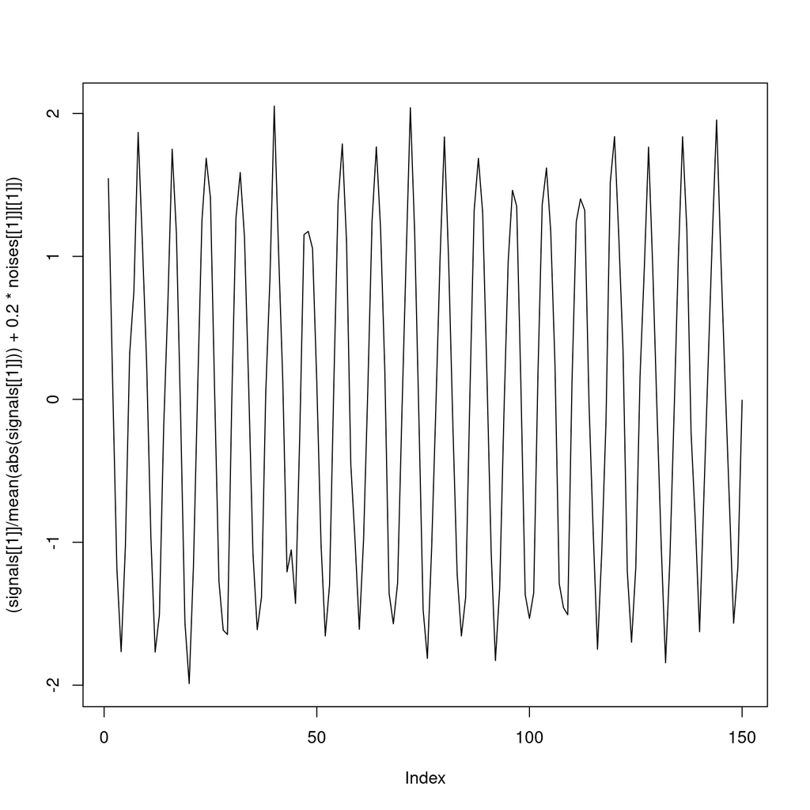

```r
periods <- c(8, 8.02, 8.04, 8.06, 8.08, 8.1, 8.15)
signals <- lapply(periods, cos_)
plot((signals[[1]] / mean(abs(signals[[1]])) + 0.2 * noises[[1]][[1]]), type="l")
```

```r
df <- get_errors(expand.grid(
    signal_id1 = 1,
    signal_id2 = 1:length(signals),
    noise_id = 1:repeats,
    noise_norm1 = c(0.2),
    noise_norm2 = 0.0,
    norm_relative = c(1),
    l_known = 100,
    l_forecast = 20,
    l_window = c(50),
    group_ssa_id = 2,
    group_mssa_id = c(2, 4),
    crutch = list(1)
))

pdf(file = "experiment_1_cos.pdf")
ggplot(df, aes(x = relative_error_reconstruct,
               y = relative_error_forecast)) +
    geom_point(aes(color = as.factor(c("1", "1:2", "1:3", "1:4")[group_mssa_id])),
               size = 5) +
    geom_point(color = "white",
               size = 4) +
    geom_point(aes(alpha = (periods[signal_id2]),
                   color = as.factor(c("1", "1:2", "1:3", "1:4")[group_mssa_id])),
               size = 4) +
    # scale_color_gradientn(colours = c("#FF0000", "#FFFFFF")) +
    scale_color_manual(values = c("red", "blue")) +
    # theme_dark() +
    geom_hline(yintercept = 0) +
    geom_vline(xintercept = 0) +
    xlim(-1, 1) + ylim(-1, 1) +
    labs(title = "Relative errors, different periods and mssa group",
    alpha = "2nd signal period",
    color = "mssa groups")
dev.off()
```

## Сравнение ошибки прогноза для mssa и ssa при разных периодах второго сигнала и разных шумах первого ряда.

Меняется шум первого ряда и период второго ряда.

Второй ряд без шума.

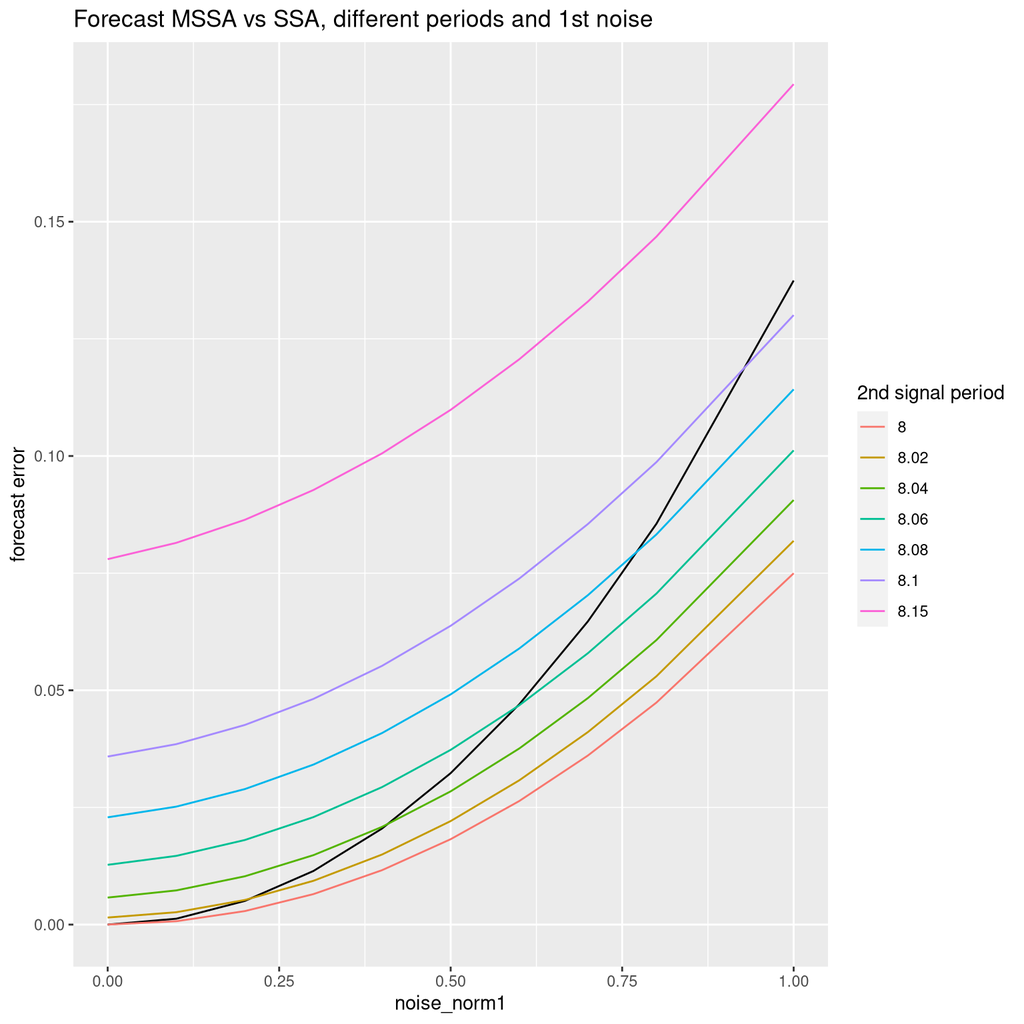

```r
periods <- c(8, 8.02, 8.04, 8.06, 8.08, 8.1, 8.15)
signals <- lapply(periods, cos_)
df <- get_errors(expand.grid(
    signal_id1 = 1,
    signal_id2 = 1:length(signals),
    noise_id = 1:repeats,
    noise_norm1 = c(0, 0.1, 0.2, 0.3, 0.4, 0.5, 0.6, 0.7, 0.8, 1),
    noise_norm2 = 0.0,
    norm_relative = c(1),
    l_known = 100,
    l_forecast = 20,
    l_window = c(50),
    group_ssa_id = 2,
    group_mssa_id = c(2),
    crutch = list(1)
))

ggplot(df) +
    geom_line(aes(x = noise_norm1,
                  y = ssa_error_forecast)) +
    geom_line(aes(x = noise_norm1,
                  y = mssa_error_forecast,
                  color = as.factor(periods[signal_id2]))) +
    labs(title = "Forecast MSSA vs SSA, different periods and 1st noise",
    y = "forecast error",
    color = "2nd signal period")
```

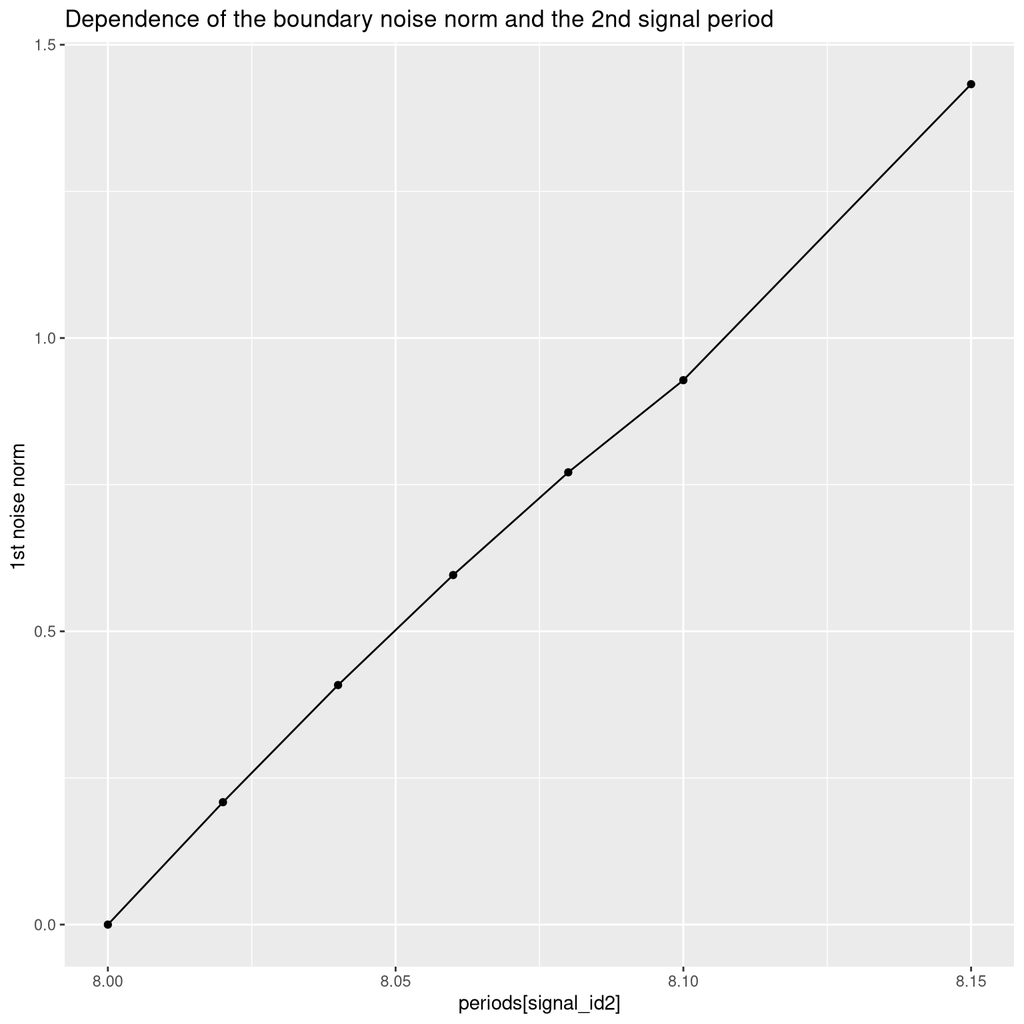

```r
ggplot(df %>%
    group_by(signal_id2) %>%
    mutate(
        noise_border = approxExtrap(x = mssa_error_forecast - ssa_error_forecast,
                                    y = noise_norm1,
                                    xout = 0)$y) %>%
    ungroup() %>%
    select(signal_id2, noise_border) %>%
    distinct(),
    aes(x = periods[signal_id2],
        y = noise_border)) +
    geom_point() +
    geom_path() +
    labs(title = "Dependence of the boundary noise norm and the 2nd signal period",
    y = "1st noise norm ",
    color = "2nd signal period")
```

Тут очень интересный результат: зависимость граничного значения шума (максимальная дисперсия шума, при котором ssa не хуже mssa) от периода второго ряда линейная.

# Эксперименты exp

```r
get_series1 <- get_series_mult1
get_series2 <- get_series_mult2
```

## Влияние разницы основания экспонент и выбора компонент на относительную ошибку

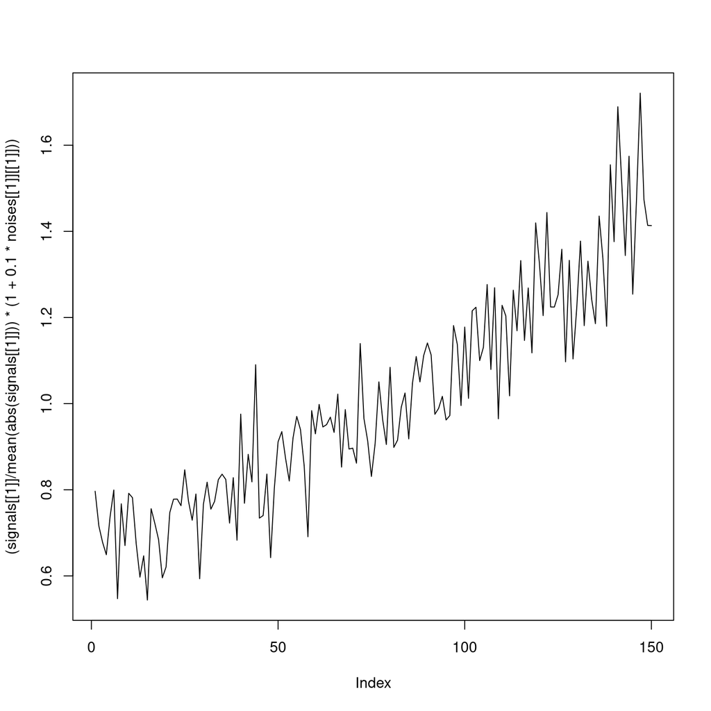

```r
bases <- c(0.005, 0.0075, 0.01, 0.0125, 0.015, 0.02, 0.025, 0.03)
signals <- lapply(bases, exp_)
plot((signals[[1]] / mean(abs(signals[[1]])) *(1+  0.1 * noises[[1]][[1]])), type="l")
```

```r
df <- get_errors(expand.grid(
    signal_id1 = 1,
    signal_id2 = 1:length(signals),
    noise_id = 1:repeats,
    noise_norm1 = c(0.2),
    noise_norm2 = 0.0,
    norm_relative = c(1),
    l_known = 100,
    l_forecast = 20,
    l_window = c(50),
    group_ssa_id = 1,
    group_mssa_id = c(1, 2),
    crutch = list(1)
))

pdf(file = "experiment_1_exp.pdf")
ggplot(df, aes(x = relative_error_reconstruct,
               y = relative_error_forecast)) +
    geom_point(aes(color = as.factor(c("1", "1:2", "1:3", "1:4")[group_mssa_id])),
               size = 5) +
    geom_point(color = "white",
               size = 4) +
    geom_point(aes(alpha = (bases[signal_id2]),
                   color = as.factor(c("1", "1:2", "1:3", "1:4")[group_mssa_id])),
               size = 4) +
    # scale_color_gradientn(colours = c("#FF0000", "#FFFFFF")) +
    scale_color_manual(values = c("red", "blue")) +
    # theme_dark() +
    geom_hline(yintercept = 0) +
    geom_vline(xintercept = 0) +
    xlim(-1, 1) + ylim(-1, 1) +
    labs(title = "Relative errors, different bases and mssa group",
    alpha = "2nd signal base",
    color = "mssa groups")
dev.off()
```

## Сравнение ошибки прогноза для mssa и ssa при разных основаниях второго сигнала и разных шумах первого ряда.

Меняется шум первого ряда и основание второго ряда.

Второй ряд без шума.

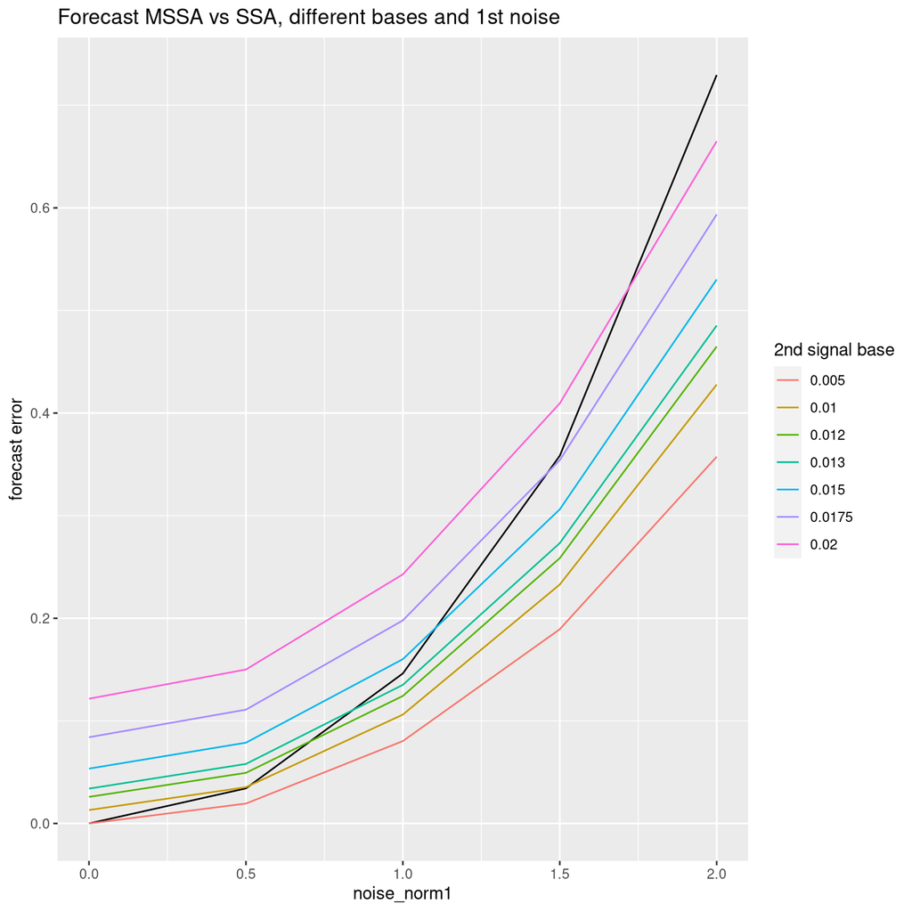

```r
# bases <- c(0.005, 0.01, 0.012, 0.013, 0.015, 0.0175, 0.02, 0.025, 0.03)
bases <- c(0.005, 0.01, 0.012, 0.013, 0.015, 0.0175, 0.02)
signals <- lapply(bases, exp_)
# plot((signals[[1]] / mean(abs(signals[[1]])) *(1+  2 * noises[[1]][[1]])), type="l")
df <- get_errors(expand.grid(
    signal_id1 = 1,
    signal_id2 = 1:length(signals),
    noise_id = 1:repeats,
    noise_norm1 = c(0, 0.5, 1, 1.5, 2),
    noise_norm2 = 0.0,
    norm_relative = c(1),
    l_known = 100,
    l_forecast = 20,
    l_window = c(50),
    group_ssa_id = 1,
    group_mssa_id = c(1),
    crutch = list(1)
))

ggplot(df) +
    geom_line(aes(x = noise_norm1,
                  y = ssa_error_forecast)) +
    geom_line(aes(x = noise_norm1,
                  y = mssa_error_forecast,
                  color = as.factor(bases[signal_id2]))) +
    labs(title = "Forecast MSSA vs SSA, different bases and 1st noise",
    y = "forecast error",
    color = "2nd signal base")
```

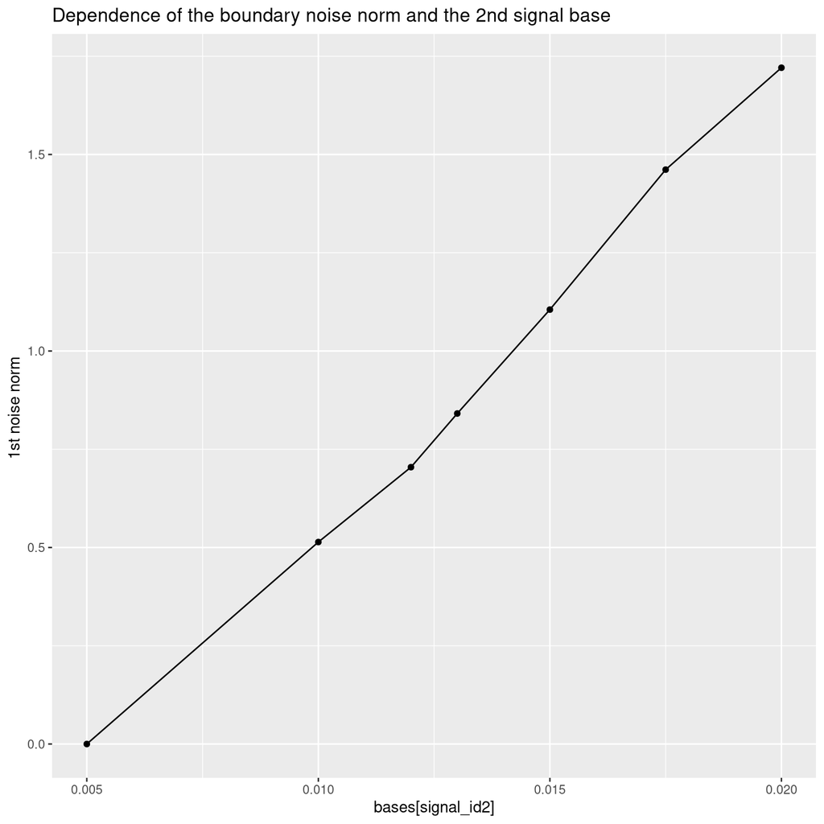

```r
ggplot(df %>%
    group_by(signal_id2) %>%
    mutate(
        noise_border = approxExtrap(x = mssa_error_forecast - ssa_error_forecast,
                                    y = noise_norm1,
                                    xout = 0,
                                    rule = 1:2)$y) %>%
    ungroup() %>%
    select(signal_id2, noise_border) %>%
    distinct(),
    aes(x = bases[signal_id2],
        y = noise_border)) +
    geom_point() +
    geom_path() +
    labs(title = "Dependence of the boundary noise norm and the 2nd signal base",
    y = "1st noise norm ",
    color = "2nd signal base")
```

Для экспонент результат аналогичный: зависимость линейная.

# Эксперименты exp * cos

```r
get_series1 <- get_series_mult1
get_series2 <- get_series_mult2
```

## Влияние разницы основания экспонент и выбора компонент на относительную ошибку

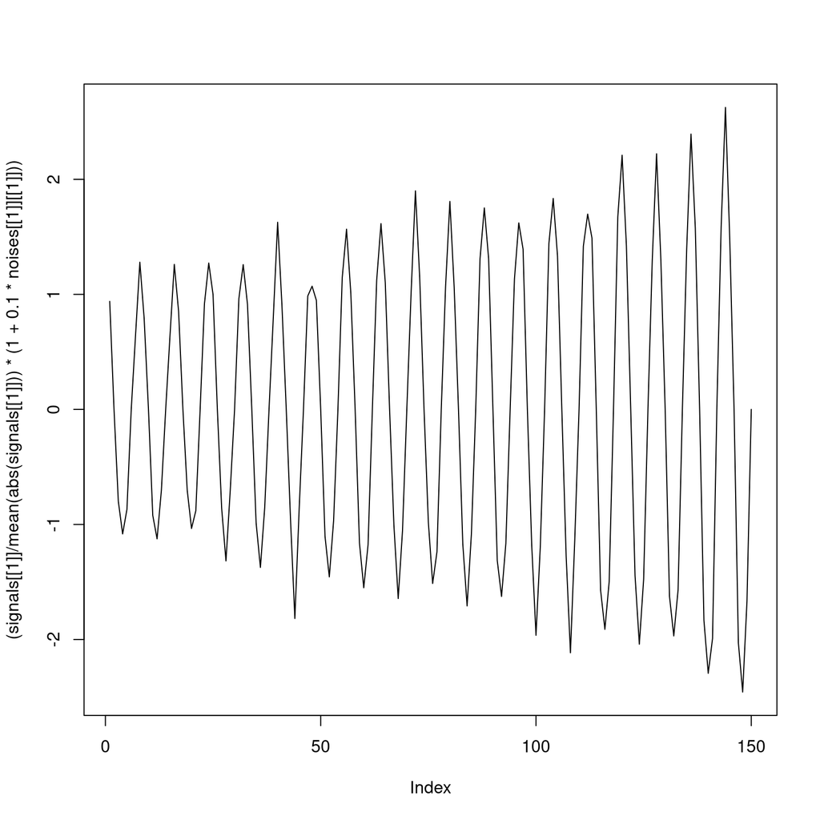

```r
bases <- c(0.005, 0.0075, 0.01, 0.0125, 0.015, 0.02, 0.025, 0.03)
signals <- lapply(bases, function(x) exp_(x) * cos_(8))
plot((signals[[1]] / mean(abs(signals[[1]])) *(1+  0.1 * noises[[1]][[1]])), type="l")
```

```r
df <- get_errors(expand.grid(
    signal_id1 = 1,
    signal_id2 = 1:length(signals),
    noise_id = 1:repeats,
    noise_norm1 = c(0.2),
    noise_norm2 = 0.0,
    norm_relative = c(1),
    l_known = 100,
    l_forecast = 20,
    l_window = c(50),
    group_ssa_id = 2,
    group_mssa_id = c(2, 4),
    crutch = list(1)
))
pdf(file = "experiment_1_expcos1.pdf")
ggplot(df, aes(x = relative_error_reconstruct,
               y = relative_error_forecast)) +
    geom_point(aes(color = as.factor(c("1", "1:2", "1:3", "1:4")[group_mssa_id])),
               size = 5) +
    geom_point(color = "white",
               size = 4) +
    geom_point(aes(alpha = (bases[signal_id2]),
                   color = as.factor(c("1", "1:2", "1:3", "1:4")[group_mssa_id])),
               size = 4) +
    # scale_color_gradientn(colours = c("#FF0000", "#FFFFFF")) +
    scale_color_manual(values = c("red", "blue")) +
    # theme_dark() +
    geom_hline(yintercept = 0) +
    geom_vline(xintercept = 0) +
    xlim(-1, 1) + ylim(-1, 1) +
    labs(title = "Relative errors, different bases and mssa group",
    alpha = "2nd signal base",
    color = "mssa groups")
dev.off()
```

## Сравнение ошибки прогноза для mssa и ssa при разных основаниях второго сигнала и разных шумах первого ряда.

Меняется шум первого ряда и основание экспоненты во втором ряду.

Второй ряд без шума.

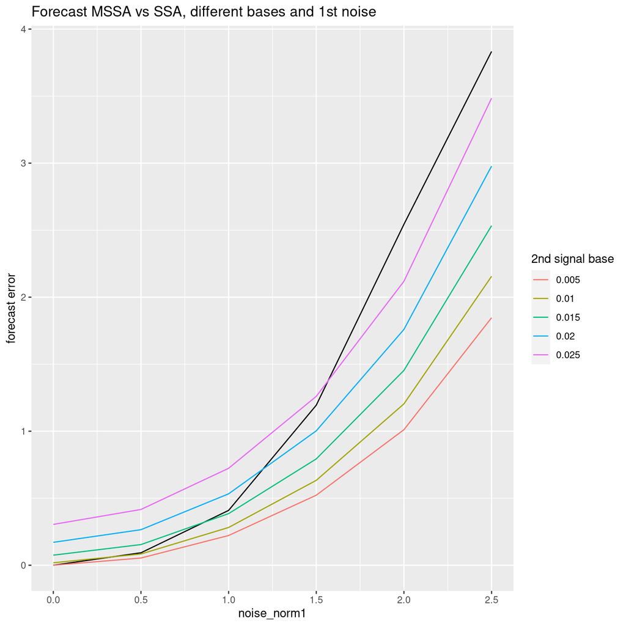

```r
# bases <- c(0.005, 0.01, 0.012, 0.013, 0.015, 0.0175, 0.02, 0.025, 0.03)
# bases <- c(0.005, 0.01, 0.012, 0.013, 0.015, 0.0175, 0.02)
bases <- c(0.005, 0.01, 0.015, 0.02, 0.025)
signals <- lapply(bases, function(x) exp_(x) * cos_(8))

# plot((signals[[1]] / mean(abs(signals[[1]])) *(1+  2 * noises[[1]][[1]])), type="l")
df <- get_errors(expand.grid(
    signal_id1 = 1,
    signal_id2 = 1:length(signals),
    noise_id = 1:repeats,
    noise_norm1 = c(0, 0.5, 1, 1.5, 2, 2.5),
    noise_norm2 = 0.0,
    norm_relative = c(1),
    l_known = 100,
    l_forecast = 20,
    l_window = c(50),
    group_ssa_id = 2,
    group_mssa_id = c(2),
    crutch = list(1)
))

ggplot(df) +
    geom_line(aes(x = noise_norm1,
                  y = ssa_error_forecast)) +
    geom_line(aes(x = noise_norm1,
                  y = mssa_error_forecast,
                  color = as.factor(bases[signal_id2]))) +
    labs(title = "Forecast MSSA vs SSA, different bases and 1st noise",
    y = "forecast error",
    color = "2nd signal base")
```

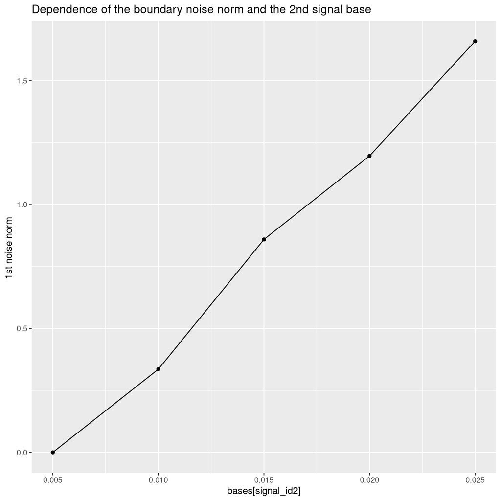

```r
ggplot(df %>%
    group_by(signal_id2) %>%
    mutate(
        noise_border = approxExtrap(x = mssa_error_forecast - ssa_error_forecast,
                                    y = noise_norm1,
                                    xout = 0,
                                    rule = 1:2)$y) %>%
    ungroup() %>%
    select(signal_id2, noise_border) %>%
    distinct(),
    aes(x = bases[signal_id2],
        y = noise_border)) +
    geom_point() +
    geom_path() +
    labs(title = "Dependence of the boundary noise norm and the 2nd signal base",
    y = "1st noise norm ",
    color = "2nd signal base")
```

Для разных оснований экспоненты, модулирующей косинусы тоже линейная зависимость.

## Сравнение ошибки прогноза для mssa и ssa при разных периодах второго сигнала и разных шумах первого ряда.

Второй сигнал отличается периодом.

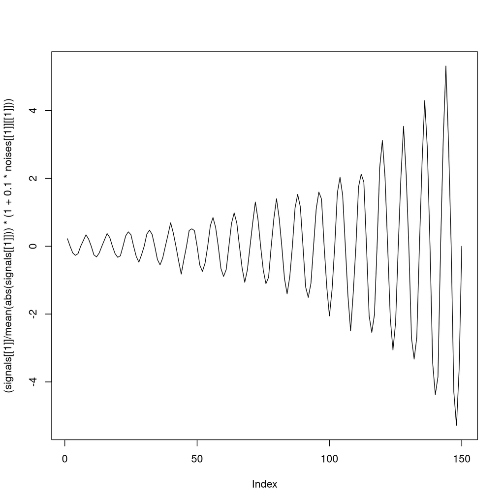

```r
# periods <- c(8, 8.02, 8.04, 8.07, 8.1, 8.15, 8.2)
periods <- c(8, 8.02, 8.04, 8.06, 8.08, 8.1, 8.15)

signals <- lapply(periods, function(x) exp_(0.02) * cos_(x))
plot((signals[[1]] / mean(abs(signals[[1]])) *(1+  0.1 * noises[[1]][[1]])), type="l")
```

```r
df <- get_errors(expand.grid(
    signal_id1 = 1,
    signal_id2 = 1:length(signals),
    noise_id = 1:repeats,
    noise_norm1 = c(0.2),
    noise_norm2 = 0.0,
    norm_relative = c(1),
    l_known = 100,
    l_forecast = 20,
    l_window = c(50),
    group_ssa_id = 2,
    group_mssa_id = c(2, 4),
    crutch = list(1)
))
pdf(file = "experiment_1_expcos2.pdf")
ggplot(df, aes(x = relative_error_reconstruct,
               y = relative_error_forecast)) +
    geom_point(aes(color = as.factor(c("1", "1:2", "1:3", "1:4")[group_mssa_id])),
               size = 5) +
    geom_point(color = "white",
               size = 4) +
    geom_point(aes(alpha = (periods[signal_id2]),
                   color = as.factor(c("1", "1:2", "1:3", "1:4")[group_mssa_id])),
               size = 4) +
    # scale_color_gradientn(colours = c("#FF0000", "#FFFFFF")) +
    scale_color_manual(values = c("red", "blue")) +
    # theme_dark() +
    geom_hline(yintercept = 0) +
    geom_vline(xintercept = 0) +
    xlim(-1, 1) + ylim(-1, 1) +
    labs(title = "Relative errors, different periods and mssa group",
    alpha = "2nd signal period",
    color = "mssa groups")
dev.off()
```

Меняется шум первого ряда.

Второй ряд без шума.

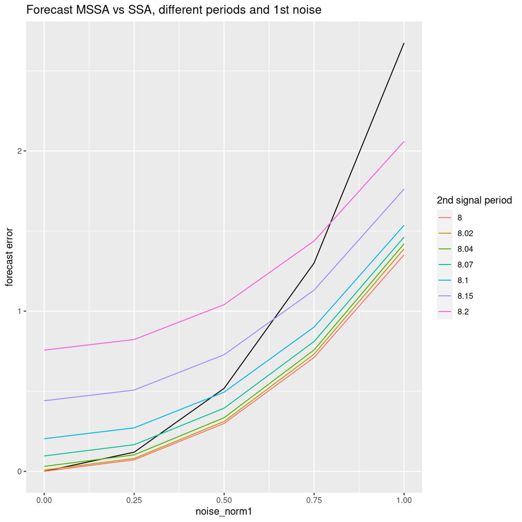

```r
periods <- c(8, 8.02, 8.04, 8.07, 8.1, 8.15, 8.2)
signals <- lapply(periods, function(x) exp_(0.02) * cos_(x))
# plot((signals[[1]] / mean(abs(signals[[1]])) *(1+  0.1 * noises[[1]][[1]])), type="l")
# plot((signals[[1]] / mean(abs(signals[[1]])) *(1+  2 * noises[[1]][[1]])), type="l")
df <- get_errors(expand.grid(
    signal_id1 = 1,
    signal_id2 = 1:length(signals),
    noise_id = 1:repeats,
    noise_norm1 = c(0, 0.25, 0.5, 0.75, 1),
    noise_norm2 = 0.0,
    norm_relative = c(1),
    l_known = 100,
    l_forecast = 20,
    l_window = c(50),
    group_ssa_id = 2,
    group_mssa_id = c(2),
    crutch = list(1)
))

ggplot(df) +
    geom_line(aes(x = noise_norm1,
                  y = ssa_error_forecast)) +
    geom_line(aes(x = noise_norm1,
                  y = mssa_error_forecast,
                  color = as.factor(periods[signal_id2]))) +
    labs(title = "Forecast MSSA vs SSA, different periods and 1st noise",
    y = "forecast error",
    color = "2nd signal period")
```

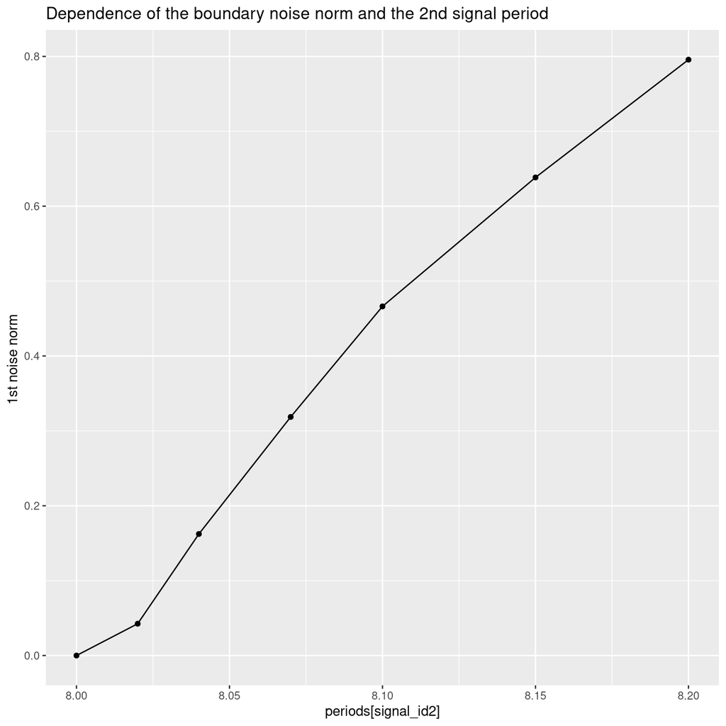

```r
ggplot(df %>%
    group_by(signal_id2) %>%
    mutate(
        noise_border = approxExtrap(x = mssa_error_forecast - ssa_error_forecast,
                                    y = noise_norm1,
                                    xout = 0,
                                    rule = 1:2)$y) %>%
    ungroup() %>%
    select(signal_id2, noise_border) %>%
    distinct(),
    aes(x = periods[signal_id2],
        y = noise_border)) +
    geom_point() +
    geom_path() +
    labs(title = "Dependence of the boundary noise norm and the 2nd signal period",
    y = "1st noise norm ",
    color = "2nd signal period")
```